# Counterfactual Confounder Adjustment for Single-cell Differential Expression Analysis

Yongjin Park

# Results

## Cell type annotation

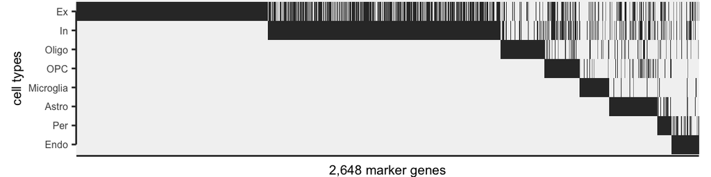

PDF

PsychENCODE’s marker gene selection might be imperfect since some “marker” genes are shared by different cell types. However, it has enough discriminatory power. Using this initial dictionary of marker genes, we can start analyzing 10x data, which consist of these three files:

- Sparse count matrix:

```
## %%MatrixMarket matrix coordinate integer general
## 17926 70634 119696200
## 56 1 1
## 139 1 1
## 270 1 1
## 324 1 1
## 375 1 1
## 389 1 1
## 420 1 1
## 557 1 1
```

- Cell barcode list:

```
## AAACGGGAGATCCCGC.1
## AAATGCCTCCAATGGT.1
## AACCATGTCAGTGCAT.1
## AACCATGTCTGTACGA.1
## AACCGCGTCCGCATAA.1
## AACGTTGGTTCAGGCC.1
## AACTGGTGTACCGGCT.1
## AAGACCTAGTTAACGA.1
## AAGGAGCAGCAATCTC.1
## AAGGAGCTCTGCTGCT.1
```

- Gene/feature list (**these names should exist in the marker file**):

```
## FO538757.2
## SAMD11
## NOC2L
## KLHL17
## PLEKHN1
## PERM1
## HES4
## ISG15
## AGRN
## RNF223
```

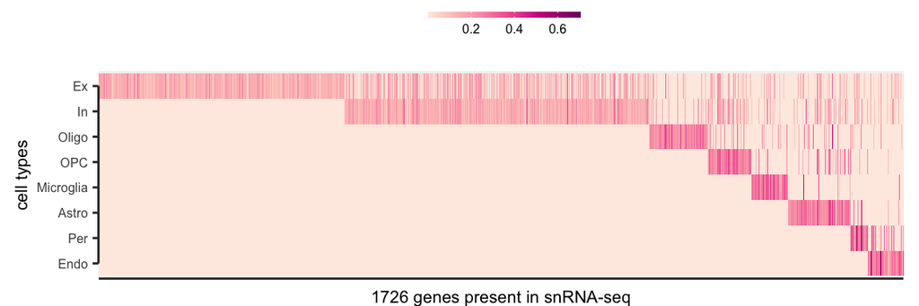

PDF

### Basic statistics for cell type annotation

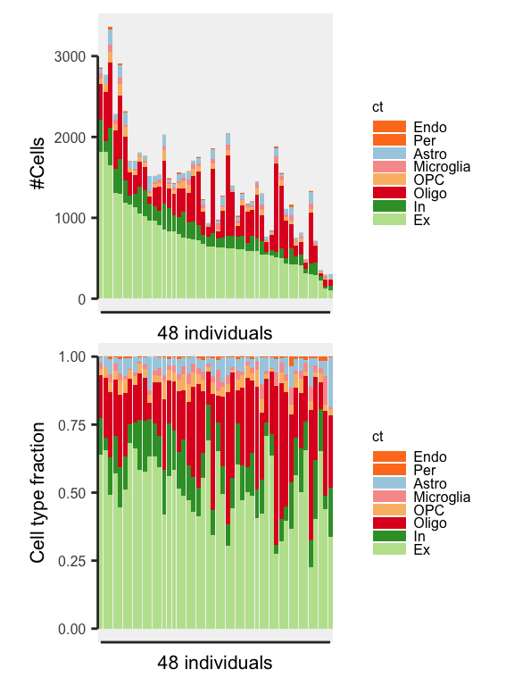

PDF

- 1,472 cells per individual, including 50.9% (N=745 $\pm$ 388) cells for Ex, 12.23% (N=179 $\pm$ 103) cells for In, 3.54% (N= 54 $\pm$ 35) cells for OPC, 0.33% (N= 4 $\pm$ 5) cells for Endo, 25.22% (N=380 $\pm$ 252) cells for Oligo, 2.61% (N= 36 $\pm$ 25) cells for Microglia, 4.95% (N= 71 $\pm$ 47) cells for Astro, 0.34% (N= 4 $\pm$ 4) cells for Per on average.

## Differential expression analysis

### CoCoA identified 377 genes are differentially-regulated between different AD conditions

- 377 genes (2.72%) consist of 123 found in Ex, 36 found in In, 86 found in Oligo, 58 found in OPC, 24 found in Microglia, 57 found in Astro

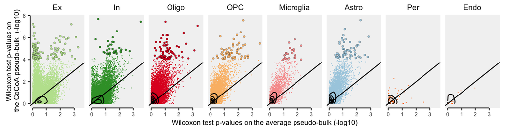

PDF

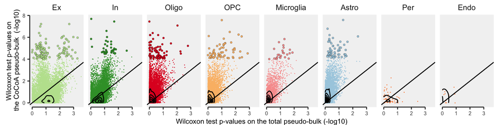

PDF

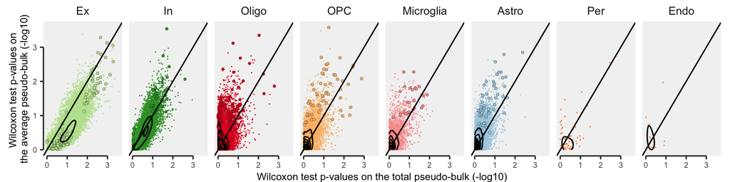

PDF

### Why do we find more genes with CoCoA?

#### Take the examples of Microglia genes

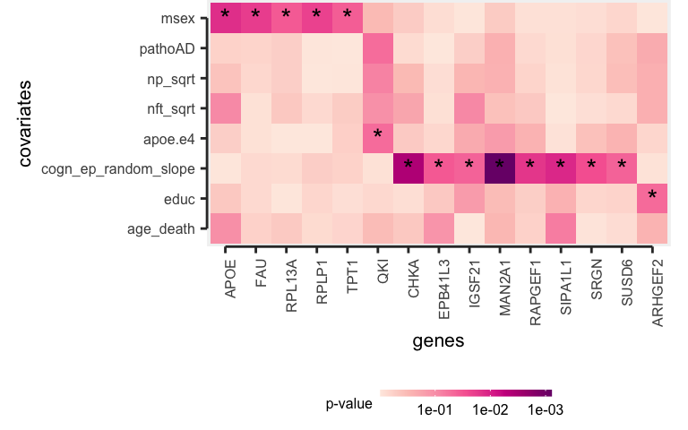

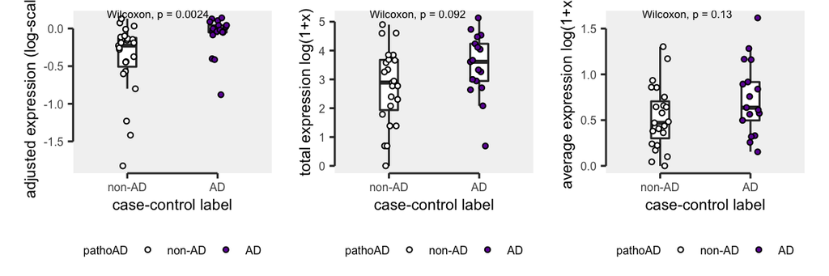

PDF

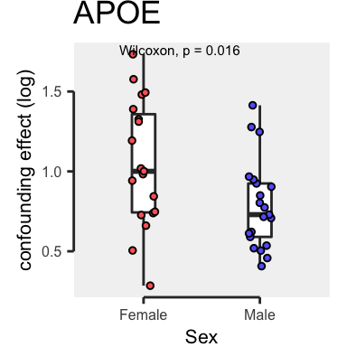

PDF

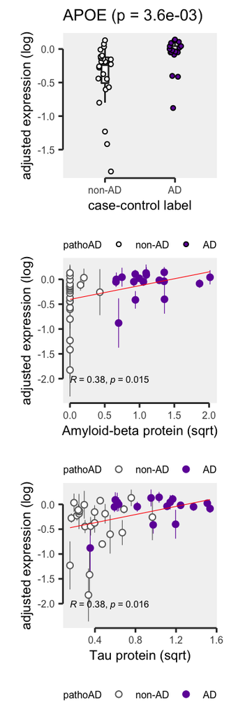

PDF

### Genomic views

Ex

Ex top genes

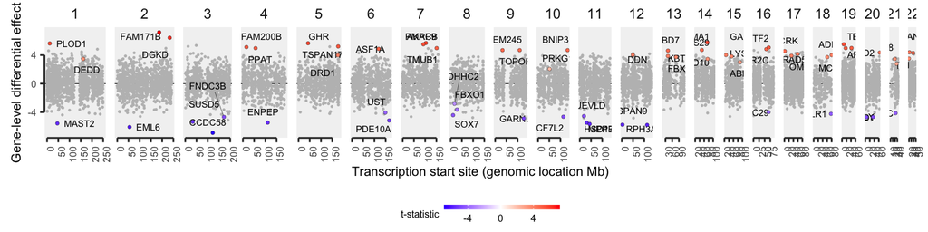

In

In top genes

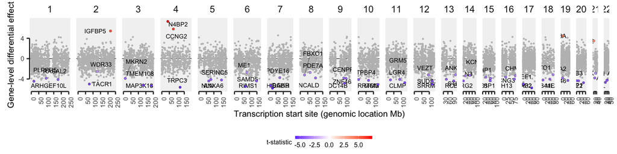

Oligo

Oligo top genes

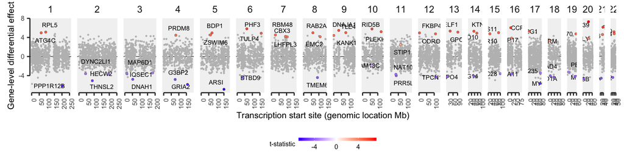

OPC

OPC top genes

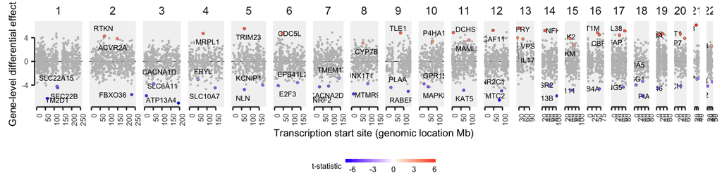

Microglia

Microglia top genes

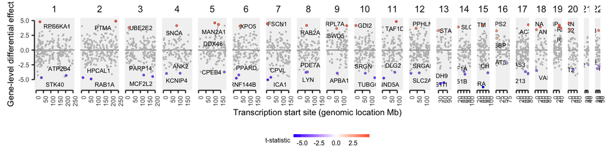

Astro

Astro top genes

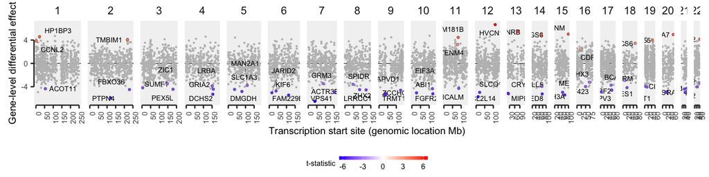

Per

Per top genes

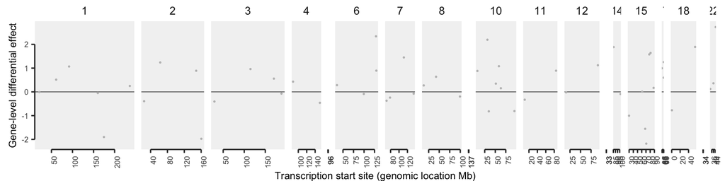

Endo

Endo top genes

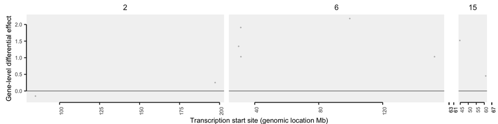

### Gene ontology enrichment

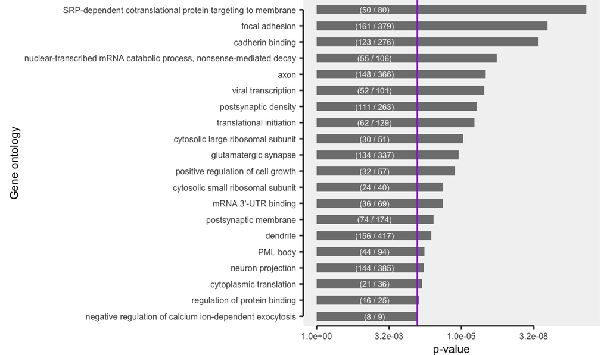

PDF